# compare_SR_NDVI_products

Erica Christensen

12/18/2019

## Compare GEE data products

There are many options for getting Landsat NDVI data from USGS using Google Earth Engine. There are 8-day and 32-day NDVI products, or you can obtain the Surface Reflectance product and calculate NDVI manually using their function. The advantage of manual calculation is that the SR product comes with a built in pixel quality band that indicates cloud, cloud shadow, and other potential problems for each pixel. I want to compare the 32-day NDVI product to manual calculation for the dates and locations for Portal.

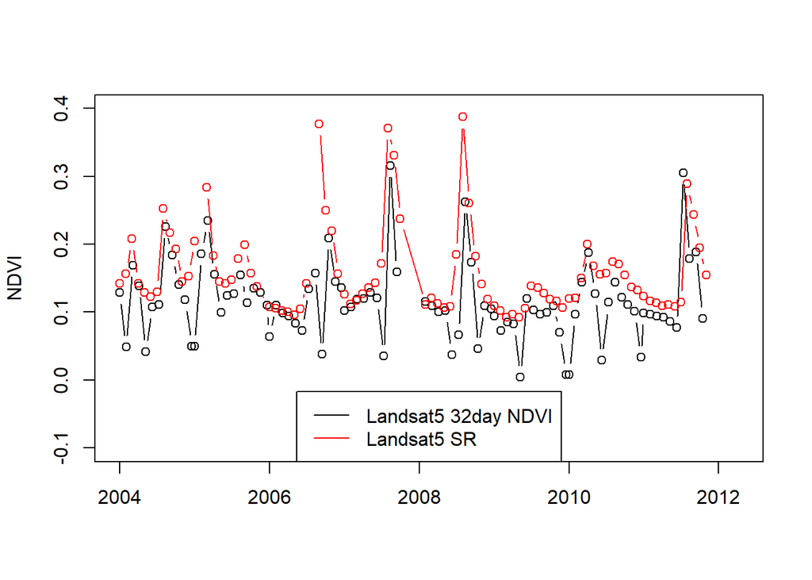

The 32-day NDVI product seems to have some outlier points that are too low. Without a QA band there is no analytical way to identify these.

## Landsat5 vs Landsat7

Landsat5 data is available for 1984-2011. This covers the first time period of the project (1995-2006) but not the second (2004-2013). I will have to use Landsat7 for the second time period, despite its SLC issue (data is available for Landsat7 1999-present). The two satellites hold the same sensors, but I still want to compare their products to confirm the data is comparable.

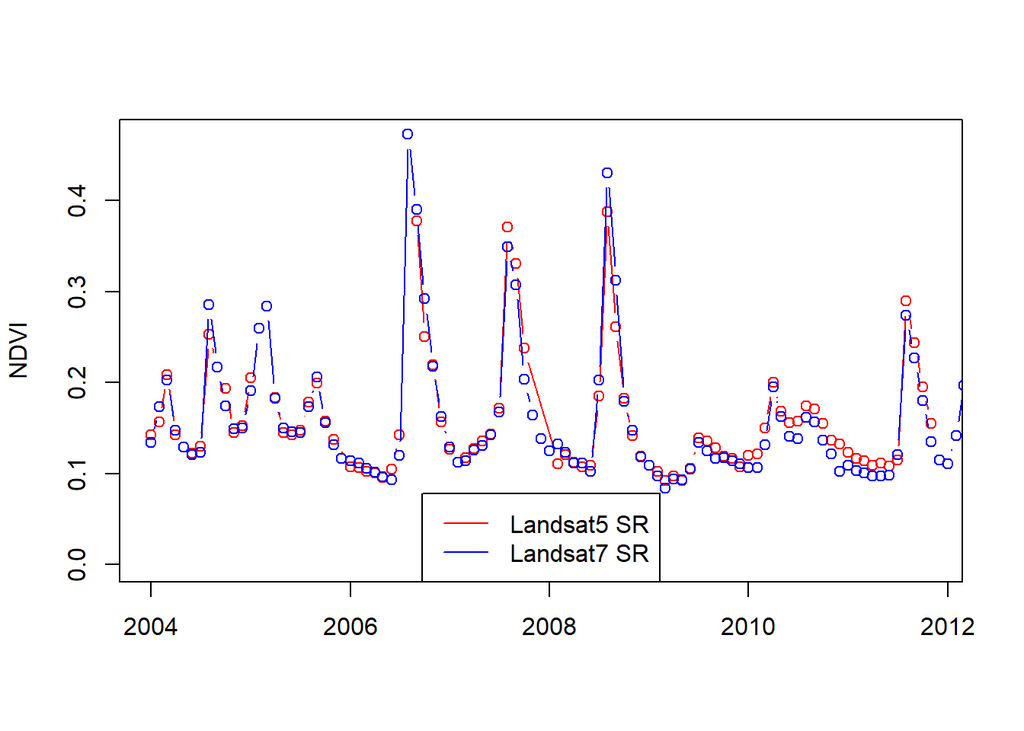

Landsat 5 and 7 seem to agree very closely, so I feel comfortable using Landsat5 for the first time period and Landsat7 for the second.